# Replication/extension report

Charlie Heller and Jyoti Tyagi - Group 8

December 13, 2018

```r
library(readxl)
library(effsize)
library(tidyverse)
```

## Exploratory Data Analysis

per P4 requirements, we first include our EDA again here.

First, load the data. Here, we simply load the data that we’ve previously tidied. In order to see how this was done (in its final form) please see the code contained in the file “P3_EDA.Rmd” (we did some revisions on tidying so this is where the tidying code now lives). This code tidies the data and caches it locally into our data folder, from which we load it here for the exploratory data analysis

```r
test_scores <- dplyr::as_tibble(read.csv(here::here("Data", "tidy_raw_test_scores.csv")))
off_task <- dplyr::as_tibble(read.csv(here::here("Data", "tidy_raw_time_off_task.csv")))
```

#### 1) Issues encountered with the data

There weren’t really any big issues. Some entries were listed as absent. During our data tidying, we converted these to NA to help us handle these cases smoothly with R. Also, the column names (now condition variable) are a little messy. It took a little work to parse them in order to make them more neat and construct a tidy data frame. In particular, it’s really a pain to parse the test scores in order to get the lesson title out, so we only did this for time off task. This shouldn’t be too much of an issue, however. We can use string matching from the pacakage `stringr` on the column `condition` if we really wish to pull out data for one particular lesson.

#### 2) Descriptive statistics from the paper (and additional ones as necessary)

- The first descriptive statistic reported is the mean age of the children (5.37 years) as well as the number of male (12) and female (12) students. The raw data provided does not allow us to reproduce these summaries. In addition, we cannot reproduce the summaries of the student’s demographic (race/ethnicity) information. However, we can confirm that the total number of participants was 24.

```r
# there are 24 disitninct study participants
length(unique(off_task$id))
```

```
## [1] 23
```

We only get 23 here because we have already removed the student who was exlcluded from analyses due to absences in the tidying step.

- The next notable summary statistic reported is the mean pre-test score. This is reported to be 22.7%. We can confirm this.

```r
test_scores %>%
  filter((pre.post=="pre")) %>%
  summarize(mean_pre_test_score = 100*mean(score))
```

```
## # A tibble: 1 x 1
##   mean_pre_test_score
##                 <dbl>
## 1                22.7
```

- For many of the anlayses in the paper the authors present descriptive visualizations/summaries, then they quantify the differences they observe with statistical tests. We’ll leave the quanitifcation for later, but walk through the descriptive visualizations here.
- First, we’ll repoduce the summary statistics/figures for time off task as a function of classroom condition graph

The authors state that overall, children were on task 66.5% percent of the time. Let’s confirm this without using the reported totals by the authors.

```r
mean_tof <-
  off_task %>%
  na.omit() %>%
  group_by(sparse.decorated, category) %>%
  mutate(score = as.numeric(as.character(score))) %>%
  summarize(means = mean(score), se = sd(score)/sqrt(length(score)))

# time ON-task across both conditions
100*(1 - 0.5 * (sum(filter(mean_tof, sparse.decorated=='decorated')$means) + sum(filter(mean_tof, sparse.decorated=='sparse')$means)))
```

```
## [1] 66.30075
```

As reported, students are ON task for about 66.3 percent of the time. We’re not sure why this isn’t coming out to exactly 66.5 as reported.

Further, we see that the time off task is quite different for the two groups:

```r
# time of task decorated
100*sum(filter(mean_tof, sparse.decorated=='decorated')$means)
```

```
## [1] 38.74722
```

```r
# time of task sparse
100*sum(filter(mean_tof, sparse.decorated=='sparse')$means)
```

```
## [1] 28.65127
```

Again, these summaries statistics don’t exactly match those reported in the paper(38.58 and 28.42, respectively). Not sure why exactly why this is happening.

Finally, we can reproduce the summary plot for this, where time off task is split into each of its categories:

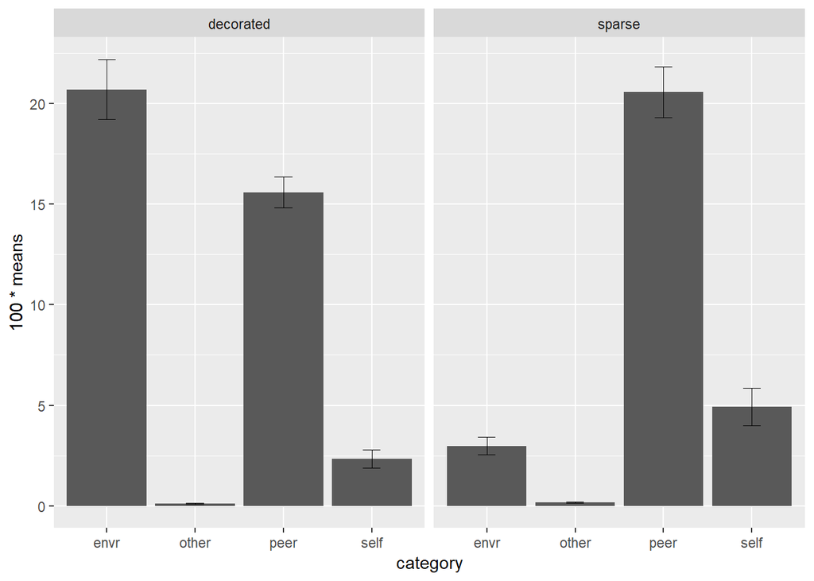

```r
ggplot(mean_tof, aes(x=category, y=100*means)) + geom_bar(stat="identity") + facet_grid(~sparse.decorated) +
  geom_errorbar(aes(ymin=100*(means-se), ymax=100*(means+se)),
                size=.3,
                width=.2)
```

- Next, the authors address pre- and post-test scores for both learning environments. They claim that the pre-test scores are statistically equivalent for the two environments (mean = 22 and mean = 23). They also claim that for the post test scores, there is a difference (55 vs. mean = 42)

```r
test_scores %>%
  select(score, pre.post, sparse.decorated) %>%
  na.omit() %>%
  group_by(pre.post, sparse.decorated) %>%
  summarize(means = 100*mean(score))
```

```
## # A tibble: 4 x 3
## # Groups:   pre.post [?]
##   pre.post sparse.decorated means
##   <fct>    <fct>            <dbl>
## 1 post     decorated         41.7
## 2 post     sparse            53.8
## 3 pre      decorated         22.8
## 4 pre      sparse            22.6
```

We see that again, this does seem to be the case. However, again our numbers are slightly different than the author’s reported figures and it’s unclear exactly why. Though, the difference is extremely small and is altogether not overly concerning. Perhaps it is due to a rounding error/discrepancy at some point in the data processing.

Though the authors don’t include this, as part of an EDA exploring this relationship we might like to make a plot something like the following:

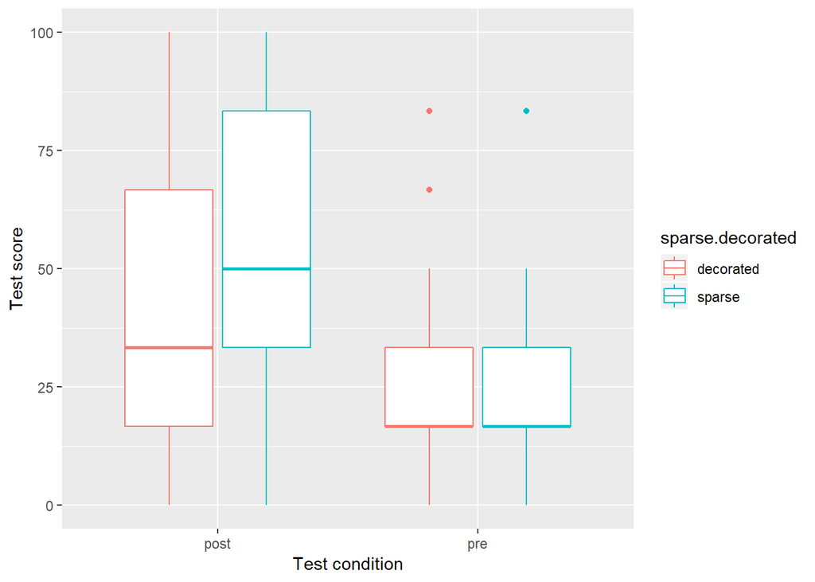

```r
ts <- test_scores %>%
  na.omit()
ggplot2::ggplot(ts, aes(x=pre.post, y=100*score, color=sparse.decorated)) + geom_boxplot() + xlab("Test condition") + ylab("Test score")
```

This firgure clearly illustrates that test scores seem to increase more for the sparse classroom condition relative to the decorated.

- Finally the authors investigate the relationship between time spent off task and learning. To do this, they first report the correlation between the mean post test scores and time off task. Therefore, they average each child’s time off task and each child’s post test score in the decorated/sparse conditions, run the correlation, and find a negative correlation of -0.5. We repeat this analysis here along with the scatter plot visualization of this relationship that they present in the paper.

[figure not shown]

```r
# calculate the mean time off task overall by student id. This involves a couple of steps

# first, calculate total time off task in decorated condition
tot_time_off_task_dec <- off_task %>%
  filter(sparse.decorated=="decorated") %>%
  select(id, category, score) %>%
  group_by(id, category) %>%
  na.omit() %>%
  summarize(means=mean(score)) %>%
  summarize(sums=100*sum(means))

# next, calculate the total time off task in the sparse condition
tot_time_off_task_spar <- off_task %>%
  filter(sparse.decorated=="sparse") %>%
  select(id, category, score) %>%
  group_by(id, category) %>%
  na.omit() %>%
  summarize(means=mean(score)) %>%
  summarize(sums=100*sum(means))

# Finally, compute the mean time off task overall
mean_time_off_task <- dplyr::left_join(tot_time_off_task_spar, tot_time_off_task_dec, by="id") %>%
  group_by(id) %>%
  summarize(means=mean(c(sums.x, sums.y)))
# calculate the mean post-test score
mean_post_test_scores <- test_scores %>%
  filter(pre.post=="post") %>%
  select(id, score) %>%
  group_by(id) %>%
  na.omit() %>%
  summarize(means=100*mean(score))

# merge the two dataframes on id to make sure the values are matched correctly
df_merged <- dplyr::left_join(mean_post_test_scores, mean_time_off_task, by="id")

# plot the data and let ggpairs compute the correlation
df_merged %>%
  select(means.y, means.x) %>%
  rename(mean_post_test_scores=means.y, mean_time_off_task=means.x) %>%
  GGally::ggpairs()
```

We see that there is clearly a negative relationship between the two variables, as the authors note.

#### 3) Issues identified with the data

All the trends the author’s observed are very clearly present in our analysis and most of the discrepancies we observed were extrememly minor and could potentially be attributed to numerical rounding differences between our approach and theirs. Overall, we did not noticed any major issues with the data.

## Replication of paper statistics and extensions

In the exploratory data analysis above, we re-made all of the figures from the paper (except one) and listed some summary stastics that were reported by the authors as well. We left the more “rigourous” statistical tests for this section (and the last plot which is more directly related to some of these tests), and will address them here. We will also re-plot each figure as necessary to make it easier to follow along.

We noted, when reading the paper, that the authors depended heavily on the use of t-tests, which are paramteric tests that assume normality in the data. However, the sample size of the data in this paper was quite small (n=23) making it difficult to determine if their data did in fact come from a normal distribution. In order to validate their results, we will include, at each point a t-test is used, a non-parametric alternative (namely, a Wilcoxon Ranksum test or a permuation test) in order to either corrabate or condtradict their reported signficance finding.

The following section is organized with the headings from the results section of the paper so that it’s made easier to follow.

### Effect of classroom type on time spent off task

The first result reported in the paper is that time off task is signficantly greater for the decorated classroom than the sparse classroom on average. Specifically, the authors state: “The overall percentage of instructional time spent off task was significantly greater when children were in the decorated classroom (M = 38.58%, SD = 10.49) than when they were in the sparse classroom (M = 28.42%, SD = 13.19), paired-sample t(22) = 4.90, p < .0001; this effect was large, Cohen’s d = 0.85.”

This result is illustrated indirectly in Figure 3 of the paper, where the authors split up off task percentage into each group. We replicate this below (as well as above).

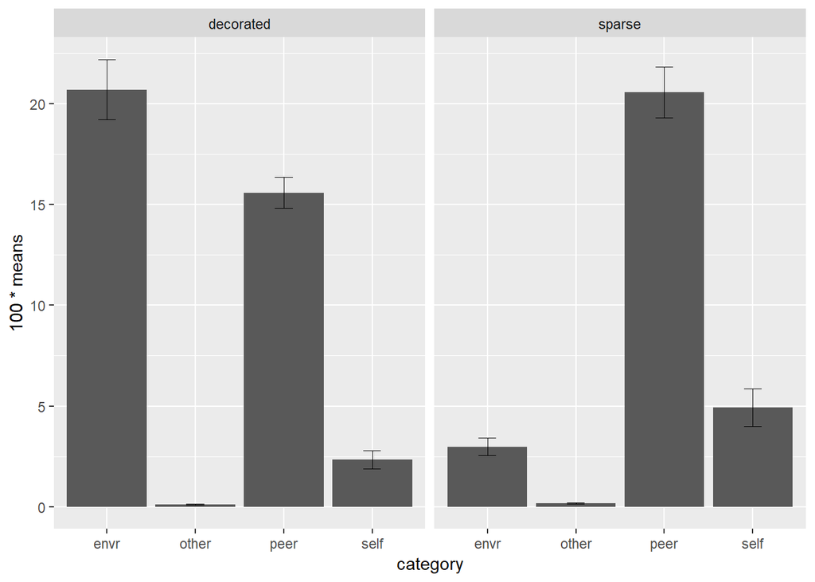

```r
ggplot(mean_tof, aes(x=category, y=100*means)) + geom_bar(stat="identity") + facet_grid(~sparse.decorated) +
  geom_errorbar(aes(ymin=100*(means-se), ymax=100*(means+se)),
                size=.3,
                width=.2)
```

In order to repeat the statistcal test the authors run, we compare across all groups (i.e. not faceted into the separate categories of time of task).

```r
dec_off_task <- off_task %>%
  na.omit() %>%
  filter(sparse.decorated=="decorated") %>%
  mutate(condition_=paste(stringr::str_split(condition, "_")[[1]][1], stringr::str_split(condition, "_")[[1]][2], sep="")) %>%
  group_by(condition_,  category,  id) %>%
  summarize(tot1=mean(score)) %>%
  group_by(category, id) %>%
  summarize(tot2=sum(tot1)) %>%
  group_by(id) %>%
  summarize(tot3 = sum(tot2))

sparse_off_task <- off_task %>%
  na.omit() %>%
  filter(sparse.decorated=="sparse") %>%
  mutate(condition_=paste(stringr::str_split(condition, "_")[[1]][1], stringr::str_split(condition, "_")[[1]][2], sep="")) %>%
  group_by(condition_,  category,  id) %>%
  summarize(tot1=mean(score)) %>%
  group_by(category, id) %>%
  summarize(tot2=sum(tot1)) %>%
  group_by(id) %>%
  summarize(tot3 = sum(tot2))

t.test(dec_off_task$tot3, sparse_off_task$tot3, paired = TRUE, alternative = "two.sided")
```

```
##
##  Paired t-test
##
## data:  dec_off_task$tot3 and sparse_off_task$tot3
## t = 4.9018, df = 22, p-value = 6.685e-05
## alternative hypothesis: true difference in means is not equal to 0
## 95 percent confidence interval:
##  0.05864505 0.14466145
## sample estimates:
## mean of the differences
##               0.1016533
```

Let’s also double check to make sure we have the correct means/sd in each group

```r
dec_off_task %>%
  summarise(mean=mean(tot3),
            sd=sd(tot3))
```

```
## # A tibble: 1 x 2
##    mean    sd
##   <dbl> <dbl>
## 1 0.386 0.105
```

```r
sparse_off_task %>%
  summarise(mean=mean(tot3),
            sd=sd(tot3))
```

```
## # A tibble: 1 x 2
##    mean    sd
##   <dbl> <dbl>
## 1 0.284 0.132
```

Indeed, we see that the difference in the overall time spent off task for the two classroom categories is signficantly different by the paired t-test and p < 0.0001 and the means/sd of each group are the same as reported in the paper. Now, let’s confirm the effect size reported with Cohen’s *d*.

```r
cohen.d(dec_off_task$tot3, sparse_off_task$tot3, paired=FALSE)
```

```
##
## Cohen's d
##
## d estimate: 0.8531435 (large)
## 95 percent confidence interval:
##       inf       sup
## 0.2323973 1.4738898
```

In order to get the Cohen’s *d* to match the paper, we must set paired=FALSE. We’re not sure this is correct given the paired nature of the data and given that they chose to perform a paired t-test. If you instead set paired=TRUE, you get an even larger effect as measured with Cohen’s *d*. Therefore, this doesn’t change the interpetation of the paper, but is worth noting nontheless.

```r
cohen.d(dec_off_task$tot3, sparse_off_task$tot3, paired=TRUE)
```

```
##
## Cohen's d
##
## d estimate: 1.022088 (large)
## 95 percent confidence interval:
##      inf      sup
## 0.390176 1.654000
```

#### Extension

Finally, we will run a paried Wilcoxon to test if the result holds for a nonparametric test

```r
wilcox.test(dec_off_task$tot3, sparse_off_task$tot3, paired=TRUE)
```

```
##
##  Wilcoxon signed rank test
##
## data:  dec_off_task$tot3 and sparse_off_task$tot3
## V = 259, p-value = 4.935e-05
## alternative hypothesis: true location shift is not equal to 0
```

Nice, we see that the results are consitent for the nonparametric test.

The authors next calculated a difference score to make sure the results weren’t driven by just a couple of hypersensitive participants. this was calculated as the percent of time spent attending the environment in the decorated condition minus the percent of time spent attending the environment in the sparse condition. They found the following: “Difference scores ranged from 2% to 36%, with a mean of 17% (SD = 9). Few children (n = 3, 13% of the sample) had difference scores below 10% and thus presumably were minimally affected by the visual displays in the decorated classroom. However, most children (n = 20, 87% of the sample) had difference scores that exceeded 10%, which is contrary to the possibility that the observed effects were driven by a minority of participants”

```r
off_task_env <- off_task %>%
  na.omit() %>%
  filter(category=="envr") %>%
  group_by(sparse.decorated, id) %>%
  summarize(difference=mean(score)*100)

dif_scores <- tidyr::spread(off_task_env, sparse.decorated, difference) %>%
  mutate(dif=decorated-sparse)

dif_scores %>%
  summarize(mean=mean(dif),
            sd = sd(dif),
            minimum = min(dif),
            maximum = max(dif))
```

```
## # A tibble: 1 x 4
##    mean    sd minimum maximum
##   <dbl> <dbl>   <dbl>   <dbl>
## 1  17.3  9.47    1.89    35.6
```

#### Extension

To illustrate this conlusion the authors make, we’ve added a dot plot whcih clearly shows that all children spent more time attending to the environment when in the decorated classroom.

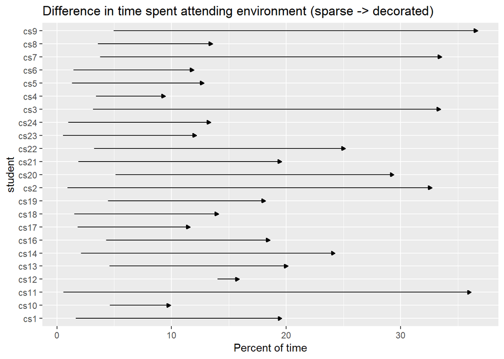

```r
# create visualiztion of this using dot plot
ggplot(off_task_env) + geom_path(aes(x=difference, y=id),
                                 arrow = arrow(length = unit(1.5, "mm"), type = "closed", ends="first")) +
  ggtitle("Difference in time spent attending environment (sparse -> decorated)") + xlab("Percent of time") + ylab("student")
```

Nice, we see that we’ve repicated the author’s results, as well as added an additional visualization to nicely illustrate that for every single subject we see an increase in time spent attenting to the environment in the deocrated classroom. This suports the author’s conclusions that their results were not simply due to a couple of outlier students.

Next the authors compare time off task faceted by subtype of distraction. They find the folliwng: “In the sparse-classroom condition, the children spent only 3.21% of instructional time engaged in environmental distractions, whereas in the decorated classroom condition, they spent 20.56% of instructional time engaged in environmental distractions; this difference was significant, paired-sample t(22) = 8.78, p < .0001, and the effect was large, Cohen’s d = −2.60.”

We confirm:

```r
dec_off_task_envr <- off_task %>%
  na.omit() %>%
  filter(sparse.decorated=="decorated") %>%
  mutate(condition_=paste(stringr::str_split(condition, "_")[[1]][1], stringr::str_split(condition, "_")[[1]][2], sep="")) %>%
  group_by(condition_,  category,  id) %>%
  summarize(tot1=mean(score)) %>%
  filter(category=="envr") %>%
  group_by(id) %>%
  summarize(tot2 = sum(tot1))

sparse_off_task_envr <- off_task %>%
  na.omit() %>%
  filter(sparse.decorated=="sparse") %>%
  mutate(condition_=paste(stringr::str_split(condition, "_")[[1]][1], stringr::str_split(condition, "_")[[1]][2], sep="")) %>%
  group_by(condition_,  category,  id) %>%
  summarize(tot1=mean(score)) %>%
  filter(category=="envr") %>%
  group_by(id) %>%
  summarize(tot2 = sum(tot1))

by_envr <- dplyr::left_join(dec_off_task_envr, sparse_off_task_envr, by="id") %>%
  summarize(mean_dec = mean(tot2.x),
            mean_sprase =  mean(tot2.y))
by_envr
```

```
## # A tibble: 1 x 2
##   mean_dec mean_sprase
##      <dbl>       <dbl>
## 1    0.206      0.0321
```

```r
# perform t test
t.test(dec_off_task_envr$tot2, sparse_off_task_envr$tot2, paired=TRUE)
```

```
##
##  Paired t-test
##
## data:  dec_off_task_envr$tot2 and sparse_off_task_envr$tot2
## t = 8.7852, df = 22, p-value = 1.206e-08
## alternative hypothesis: true difference in means is not equal to 0
## 95 percent confidence interval:
##  0.1324798 0.2143558
## sample estimates:
## mean of the differences
##               0.1734178
```

```r
# and cohen's d
cohen.d(dec_off_task_envr$tot2, sparse_off_task_envr$tot2, paired=FALSE)
```

```
##
## Cohen's d
##
## d estimate: 2.593553 (large)
## 95 percent confidence interval:
##      inf      sup
## 1.787227 3.399878
```

Note that again with the Cohen’s d, we must set `paried=False` in order to get the author’s result. In this case, if we set `paired=TRUE` we get a smaller (butnstill large) effect size.

```r
cohen.d(dec_off_task_envr$tot2, sparse_off_task_envr$tot2, paired=TRUE)
```

```
##
## Cohen's d
##
## d estimate: 1.831831 (large)
## 95 percent confidence interval:
##      inf      sup
## 1.123779 2.539884
```

#### Extension

Again, we test with wilcoxon as well

```r
wilcox.test(dec_off_task_envr$tot2, sparse_off_task_envr$tot2, paired=TRUE)
```

```
##
##  Wilcoxon signed rank test
##
## data:  dec_off_task_envr$tot2 and sparse_off_task_envr$tot2
## V = 276, p-value = 2.384e-07
## alternative hypothesis: true location shift is not equal to 0
```

Again, the non-paramteric test holds up.

To conclude this section the authors state: “children spent significantly more time engaging in self-distraction and peer distraction in the sparse classroom than they did in the decorated classroom, both paired-sample ts(22) > 2.75, ps < .012”

```r
dec_off_task_self <- off_task %>%
  na.omit() %>%
  filter(sparse.decorated=="decorated") %>%
  mutate(condition_=paste(stringr::str_split(condition, "_")[[1]][1], stringr::str_split(condition, "_")[[1]][2], sep="")) %>%
  group_by(condition_,  category,  id) %>%
  summarize(tot1=mean(score)) %>%
  filter(category=="self") %>%
  group_by(id) %>%
  summarize(tot2 = sum(tot1))

sparse_off_task_self <- off_task %>%
  na.omit() %>%
  filter(sparse.decorated=="sparse") %>%
  mutate(condition_=paste(stringr::str_split(condition, "_")[[1]][1], stringr::str_split(condition, "_")[[1]][2], sep="")) %>%
  group_by(condition_,  category,  id) %>%
  summarize(tot1=mean(score)) %>%
  filter(category=="self") %>%
  group_by(id) %>%
  summarize(tot2 = sum(tot1))

# perform t test
t.test(dec_off_task_self$tot2, sparse_off_task_self$tot2, paired=TRUE)
```

```
##
##  Paired t-test
##
## data:  dec_off_task_self$tot2 and sparse_off_task_self$tot2
## t = -2.7487, df = 22, p-value = 0.01172
## alternative hypothesis: true difference in means is not equal to 0
## 95 percent confidence interval:
##  -0.044072060 -0.006166939
## sample estimates:
## mean of the differences
##              -0.0251195
```

```r
dec_off_task_peer <- off_task %>%
  na.omit() %>%
  filter(sparse.decorated=="decorated") %>%
  mutate(condition_=paste(stringr::str_split(condition, "_")[[1]][1], stringr::str_split(condition, "_")[[1]][2], sep="")) %>%
  group_by(condition_,  category,  id) %>%
  summarize(tot1=mean(score)) %>%
  filter(category=="peer") %>%
  group_by(id) %>%
  summarize(tot2 = sum(tot1))

sparse_off_task_peer <- off_task %>%
  na.omit() %>%
  filter(sparse.decorated=="sparse") %>%
  mutate(condition_=paste(stringr::str_split(condition, "_")[[1]][1], stringr::str_split(condition, "_")[[1]][2], sep="")) %>%
  group_by(condition_,  category,  id) %>%
  summarize(tot1=mean(score)) %>%
  filter(category=="peer") %>%
  group_by(id) %>%
  summarize(tot2 = sum(tot1))

# perform t test
t.test(dec_off_task_peer$tot2, sparse_off_task_peer$tot2, paired=TRUE)
```

```
##
##  Paired t-test
##
## data:  dec_off_task_peer$tot2 and sparse_off_task_peer$tot2
## t = -3.8193, df = 22, p-value = 0.0009361
## alternative hypothesis: true difference in means is not equal to 0
## 95 percent confidence interval:
##  -0.07116910 -0.02107912
## sample estimates:
## mean of the differences
##             -0.04612411
```

This is all summarized in the bar plot shown above.

#### Extension

```r
wilcox.test(dec_off_task_self$tot2, sparse_off_task_self$tot2, paired=TRUE)
```

```
##
##  Wilcoxon signed rank test
##
## data:  dec_off_task_self$tot2 and sparse_off_task_self$tot2
## V = 31, p-value = 0.0005517
## alternative hypothesis: true location shift is not equal to 0
```

```r
wilcox.test(dec_off_task_peer$tot2, sparse_off_task_peer$tot2, paired=TRUE)
```

```
##
##  Wilcoxon signed rank test
##
## data:  dec_off_task_peer$tot2 and sparse_off_task_peer$tot2
## V = 32, p-value = 0.0006387
## alternative hypothesis: true location shift is not equal to 0
```

Again, non-paramteric test results are consistent with t test.

### Effect of classroom type on learning

In this section the autiors explore the effect of classroom type on the student’s ability to learn by analyzing pre and post experiment test scores. For this section, they reference the followig graphic:

```r
test_score1<- test_scores %>%
  select(score, pre.post, sparse.decorated) %>%
  na.omit() %>%
  group_by(pre.post, sparse.decorated) %>%
  summarize(Means = 100*mean(score))
test_score1
```

```
## # A tibble: 4 x 3
## # Groups:   pre.post [?]
##   pre.post sparse.decorated Means
##   <fct>    <fct>            <dbl>
## 1 post     decorated         41.7
## 2 post     sparse            53.8
## 3 pre      decorated         22.8
## 4 pre      sparse            22.6
```

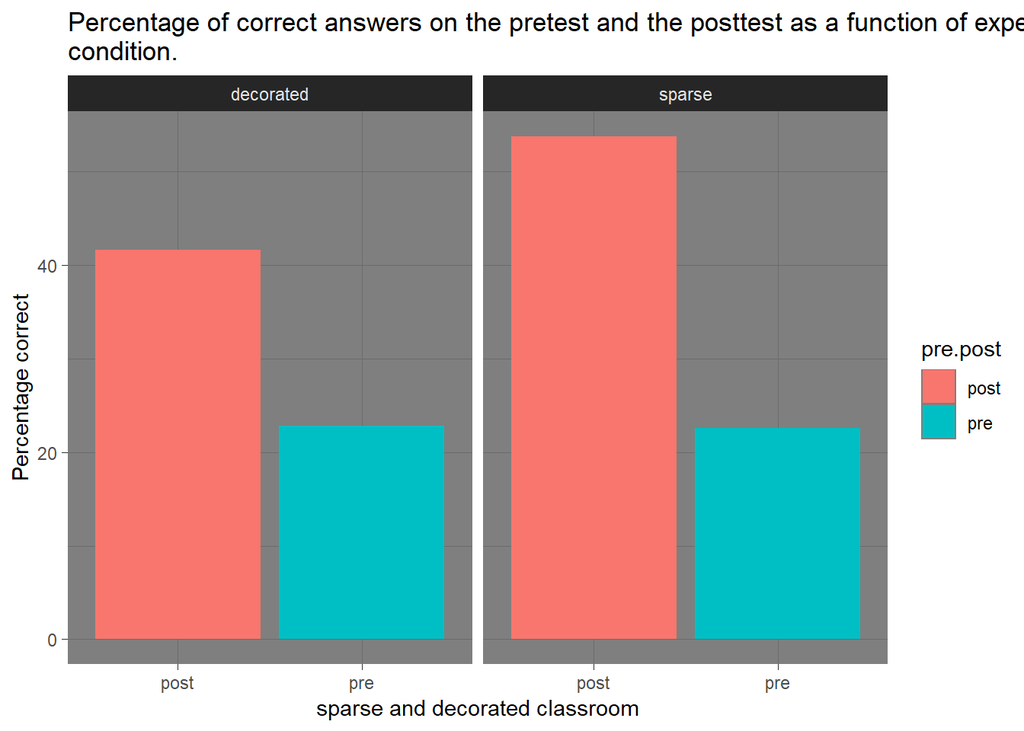

```r
ggplot(test_score1, aes(x=pre.post, y= Means, fill= pre.post))+ facet_wrap(~sparse.decorated)+
  geom_bar(stat="identity")+
  theme_dark()+
  ggtitle("Percentage of correct answers on the pretest and the posttest as a function of experimental
condition. ")+
  labs(y= "Percentage correct", x= "sparse and decorated classroom")
```

As a first pass at the analysis, they confirm that there was no pre-existing difference in the poopulation by comparing just pre-test scores: “Pretest accuracy was statistically equivalent in the sparse classroom condition (M = 22%) and the decorated-classroom condition (M = 23%), paired-samples t(22) < 1, and accuracy in both conditions was not different from chance, both one-sample ts (22) < 1.3, ps > .21”

Without more information about the test structure, we can’t confirm that performance was equal to chance level. However, we con confirm the first part of this statement by the authors:

```r
sp_pre_scores <- test_scores %>%
  filter(pre.post=="pre") %>%
  filter(sparse.decorated=="sparse")
dec_pre_scores <- test_scores %>%
  filter(pre.post=="pre") %>%
  filter(sparse.decorated=="decorated")
pre_scores <- dplyr::left_join(sp_pre_scores, dec_pre_scores, by="id") %>%
  summarize(mean_sp = mean(score.x),
            mean_dec = mean(score.y))
pre_scores
```

```
## # A tibble: 1 x 2
##   mean_sp mean_dec
##     <dbl>    <dbl>
## 1   0.226    0.228
```

```r
# do ttest:
t.test(sp_pre_scores$score, dec_pre_scores$score, paired=TRUE)
```

```
##
##  Paired t-test
##
## data:  sp_pre_scores$score and dec_pre_scores$score
## t = -0.10431, df = 68, p-value = 0.9172
## alternative hypothesis: true difference in means is not equal to 0
## 95 percent confidence interval:
##  -0.05348524  0.04817123
## sample estimates:
## mean of the differences
##            -0.002657005
```

#### Extension

```r
wilcox.test(sp_pre_scores$score, dec_pre_scores$score, paired=TRUE)
```

```
##
##  Wilcoxon signed rank test with continuity correction
##
## data:  sp_pre_scores$score and dec_pre_scores$score
## V = 737, p-value = 0.8514
## alternative hypothesis: true location shift is not equal to 0
```

Again, non-parametric results are consistent

Next, the authors show that post test scores were significantly higher than pre-test scores regardless of condition: “children’s posttest scores were significantly higher than their pretest scores in both experimental conditions, both paired-samples ts(22) > 4.72, ps ≤ .0001.

```r
pre <- test_scores %>%
  na.omit() %>%
  filter(pre.post=="pre") %>%
  group_by(id) %>%
  summarize(m = mean(score))

post <- test_scores %>%
  na.omit() %>%
  filter(pre.post=="post") %>%
  group_by(id) %>%
  summarize(m = mean(score))

scores_overall <- dplyr::left_join(pre, post, by="id")

t.test(scores_overall$m.y, scores_overall$m.x, paired=TRUE)
```

```
##
##  Paired t-test
##
## data:  scores_overall$m.y and scores_overall$m.x
## t = 7.1715, df = 22, p-value = 3.449e-07
## alternative hypothesis: true difference in means is not equal to 0
## 95 percent confidence interval:
##  0.1826839 0.3313258
## sample estimates:
## mean of the differences
##               0.2570048
```

#### Extension

```r
wilcox.test(scores_overall$m.y, scores_overall$m.x, paired=TRUE)
```

```
##
##  Wilcoxon signed rank test with continuity correction
##
## data:  scores_overall$m.y and scores_overall$m.x
## V = 273, p-value = 4.294e-05
## alternative hypothesis: true location shift is not equal to 0
```

Non-parametric test is consitent with parametric test.

The punch line of this section is that there was a difference in pre/post test scores for the decorated vs. sparse condtions: “However, their learning scores were higher in the sparse-classroom condition (M = 55%) than in the decorated-classroom condition (M = 42%), paired-samples t(22) = 2.95, p = .007; this effect was of medium size, Cohen’s d = 0.65”

```r
post_dec <- test_scores %>%
  na.omit() %>%
  filter(pre.post=="post" & sparse.decorated=="decorated") %>%
  group_by(id) %>%
  summarize(m = mean(score))

post_sparse <- test_scores %>%
  na.omit() %>%
  filter(pre.post=="post" & sparse.decorated=="sparse") %>%
  group_by(id) %>%
  summarize(m = mean(score))

post_scores <- dplyr::left_join(post_dec, post_sparse, by="id") %>%
  summarize(mean_dec = mean(m.x),
            mean_sparse = mean(m.y))

# tttest
t.test(post_sparse$m, post_dec$m, paired=TRUE)
```

```
##
##  Paired t-test
##
## data:  post_sparse$m and post_dec$m
## t = 2.9518, df = 22, p-value = 0.007372
## alternative hypothesis: true difference in means is not equal to 0
## 95 percent confidence interval:
##  0.03807575 0.21796290
## sample estimates:
## mean of the differences
##               0.1280193
```

```r
# cohens d
cohen.d(post_sparse$m, post_dec$m,  paried=TRUE)
```

```
##
## Cohen's d
##
## d estimate: 0.6338453 (medium)
## 95 percent confidence interval:
##        inf        sup
## 0.02480577 1.24288484
```

#### Extension

```r
wilcox.test(post_sparse$m, post_dec$m, paired=TRUE)
```

```
##
##  Wilcoxon signed rank test with continuity correction
##
## data:  post_sparse$m and post_dec$m
## V = 188, p-value = 0.01232
## alternative hypothesis: true location shift is not equal to 0
```

Here, consistency with the author’s results would depend on their alpha level, which the authors don’t specifically state. We’re signigicant at the 0.05 level but not at 0.01 with a non-parametric test.

Finally, they compute a gain score (difference in pre/post test scores), and repeat the analysis: “Pairwise comparisons indicated that the children’s learning gains were higher in the sparse-classroom condition (M = 33%, SD = 22) than in the decorated-classroom condition (M = 18%, SD = 19), paired-sample t(22) = 3.49, p = .002, Cohen’s d = 0.73”

```r
pre_dec<- test_scores %>%
  na.omit() %>%
  filter(pre.post=="pre" & sparse.decorated=="decorated") %>%
  group_by(id) %>%
  summarize(m = mean(score))
pre_sparse <- test_scores %>%
  na.omit() %>%
  filter(pre.post=="pre" & sparse.decorated=="sparse") %>%
  group_by(id) %>%
  summarize(m = mean(score))

# using the post_dec dataframe from the code cell above:
gain_scores <- dplyr::left_join(pre_dec, pre_sparse, by="id") %>%
                                  dplyr::left_join(post_dec, by="id") %>%
                                  dplyr::left_join(post_sparse, by="id") %>%
  mutate(dec_gain = m.x.x - m.x,
         sp_gain = m.y.y - m.y)

gain_scores %>%
  summarize(mean_dec_gain = mean(dec_gain),
            sd_dec_gain = sd(dec_gain),
            mean_sp_gain = mean(sp_gain),
            sd_sp_gain = sd(sp_gain))
```

```
## # A tibble: 1 x 4
##   mean_dec_gain sd_dec_gain mean_sp_gain sd_sp_gain
##           <dbl>       <dbl>        <dbl>      <dbl>
## 1         0.190       0.194        0.320      0.207
```

```r
# run ttest
t.test(gain_scores$sp_gain, gain_scores$dec_gain, paired=TRUE)
```

```
##
##  Paired t-test
##
## data:  gain_scores$sp_gain and gain_scores$dec_gain
## t = 3.1628, df = 22, p-value = 0.00451
## alternative hypothesis: true difference in means is not equal to 0
## 95 percent confidence interval:
##  0.04499172 0.21636093
## sample estimates:
## mean of the differences
##               0.1306763
```

```r
#effect size
cohen.d(gain_scores$sp_gain, gain_scores$dec_gain, paired=TRUE)
```

```
##
## Cohen's d
##
## d estimate: 0.6594963 (medium)
## 95 percent confidence interval:
##        inf        sup
## 0.04925553 1.26973711
```

#### Extension

```r
wilcox.test(gain_scores$sp_gain, gain_scores$dec_gain, paired=TRUE)
```

```
##
##  Wilcoxon signed rank test with continuity correction
##
## data:  gain_scores$sp_gain and gain_scores$dec_gain
## V = 227, p-value = 0.007102
## alternative hypothesis: true location shift is not equal to 0
```

Again, results here are consistent.

### The relation between time spent off task and learning

First the author’s investigate the relationship between total time spent off task and post test scores as a measure of whether the two variables are related. They find: “Children who spent more time off task tended to have lower learning scores, r = −.500, p = .015”

To confirm this we first report the correlation, then create a linear model to determine the significance of the relationship. Recall that we created this graph in our EDA (and we recreate the scatter here) so we already have the necessary variables

```r
cor(mean_time_off_task$means, mean_post_test_scores$means)
```

```
## [1] -0.5020212
```

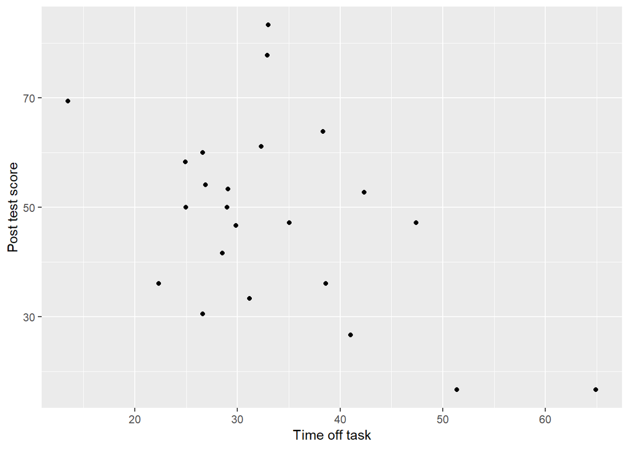

```r
plot_df <- dplyr::left_join(mean_time_off_task, mean_post_test_scores, by="id")

ggplot(plot_df, aes(x=means.x, y=means.y)) + geom_point() + xlab("Time off task") + ylab("Post test score")
```

```r
model <- lm(mean_time_off_task$means ~ mean_post_test_scores$means)
summary(model)
```

```
##
## Call:
## lm(formula = mean_time_off_task$means ~ mean_post_test_scores$means)
##
## Residuals:
##     Min      1Q  Median      3Q     Max
## -15.004  -6.257  -2.890   8.263  21.445
##
## Coefficients:
##                             Estimate Std. Error t value Pr(>|t|)
## (Intercept)                  48.6546     6.0380   8.058 7.33e-08 ***
## mean_post_test_scores$means  -0.3132     0.1177  -2.660   0.0146 *
## ---
## Signif. codes:  0 '***' 0.001 '**' 0.01 '*' 0.05 '.' 0.1 ' ' 1
##
## Residual standard error: 9.585 on 21 degrees of freedom
## Multiple R-squared:  0.252,  Adjusted R-squared:  0.2164
## F-statistic: 7.076 on 1 and 21 DF,  p-value: 0.01465
```

Here we have replicated the correlation and in addition the p-value for our slope in the linear model matches that reported by the authors, suggesting we have used the same test (they did not specify in the paper)

#### Extension

There’s not exactly a Wilcoxon equivalent for slope testing (as far as I’m aware). So, we’ll instead use a permutation method to validate their claim that there is a significant correlation between the two variables. Essentially, we permute the data many times, so that the null hypothesis is true, and then ask how often under the null hypothesis do we see a slope as large as the one calculated for the actual data. This is our p-value.

Permutation test:

```r
# define the observed slope
obs_slope <- plot_df %>%
  infer::specify(means.y ~ means.x) %>%
  infer::calculate(stat="slope")
obs_slope <- obs_slope$stat
```

The observed slope is:

```r
print("the observed slope is: ")
obs_slope
```

[output not shown]

```r
# generate a distribution of slopes with permuted data
slopes <- plot_df %>%
  infer::specify(means.y ~ means.x) %>%
  infer::hypothesize(null = "independence") %>%
  infer::generate(reps = 1000, type = "permute") %>%
  infer::calculate(stat = "slope")
```

The p-value is:

```r
# calculate a p-value for our observed slope
sum(abs(slopes$stat)>abs(obs_slope)) / dim(slopes)[1]
```

[output not shown]

```r
boot_slopes <- plot_df %>%
  infer::specify(means.y ~ means.x) %>%
  infer::generate(reps = 1000, type = "bootstrap") %>%
  infer::calculate(stat = "slope")

boot_slopes %>%
  summarize(estimated_slope = mean(stat),
            stderror = sd(stat) / sqrt(1000))
```

```
## # A tibble: 1 x 2
##   estimated_slope stderror
##             <dbl>    <dbl>
## 1          -0.739  0.00959
```